# final_project_ahmad_tokey

2022-11-15

# setting up the environment

```r
#install.packages("pak")
#pak::pkg_install("r-lib/rlang")

#install.packages("devtools")
#install.packages("C:/Users/tokey/Downloads/cli_3.4.1.tar.gz", repos=NULL, type = "source")
#devtools::install_github("r-lib/vctrs")

#install.packages("C:/Users/tokey/Downloads/rlang_1.0.6.tar.gz", type = "source")
#library(rlang)
library(lubridate)
library(sf)
library(tidyverse)
```

```r
library(tmap) #plot map
library(tidycensus) #acs data
library(tigris)   # shapefiles
library(dplyr)
library(rgeos)
library(rgdal)
library(raster)
library(lattice)
library(ncdf4)
library(corrplot)
library(ggpubr)
library(exactextractr) # calculate zonal statistics with raster data

library(corrplot) # for correlation plot

# Import lattice
library(lattice)
library(grid)
library(GISTools)
#install.packages("fastDummies")
library(fastDummies)
```

```r
#setting working directory

setwd("C:/study/1_OSU/fall 22/lab2/final project")
```

# Getting started with food inspection data

```r
#import the csv data
raw_fi <- read.csv("Food_Inspections.csv")
```

```r
#examine the data
colnames(raw_fi) #check the name of column containing latlong
```

```
##  [1] "Inspection.ID"   "DBA.Name"        "AKA.Name"        "License.."
##  [5] "Facility.Type"   "Risk"            "Address"         "City"
##  [9] "State"           "Zip"             "Inspection.Date" "Inspection.Type"
## [13] "Results"         "Violations"      "Latitude"        "Longitude"
## [17] "Location"
```

```r
class(raw_fi$Latitude) #check the data type of latlong
```

```
## [1] "numeric"
```

```r
class(raw_fi$Longitude)
```

```
## [1] "numeric"
```

```r
summary(raw_fi$Latitude) #check how many NA values are there
```

```
##    Min. 1st Qu.  Median    Mean 3rd Qu.    Max.    NA's
##   41.64   41.83   41.89   41.88   41.94   42.02     833
```

```r
summary(raw_fi$Longitude)
```

```
##    Min. 1st Qu.  Median    Mean 3rd Qu.    Max.    NA's
##  -87.91  -87.71  -87.67  -87.68  -87.64  -87.53     833
```

```r
# get the date field in right format
raw_fi$Inspection.Date <- as.Date(raw_fi$Inspection.Date, "%m/%d/%Y")

#number of rows
nrow(raw_fi)
```

```
## [1] 244683
```

```r
# plotting number of records by year
raw_fi$year <- format(raw_fi$Inspection.Date,"%Y")

sum_yr <- as.data.frame(table(raw_fi$year))

head(sum_yr)
```

```
##   Var1  Freq
## 1 2010 18067
## 2 2011 18748
## 3 2012 18866
## 4 2013 20948
## 5 2014 21540
## 6 2015 20911
```

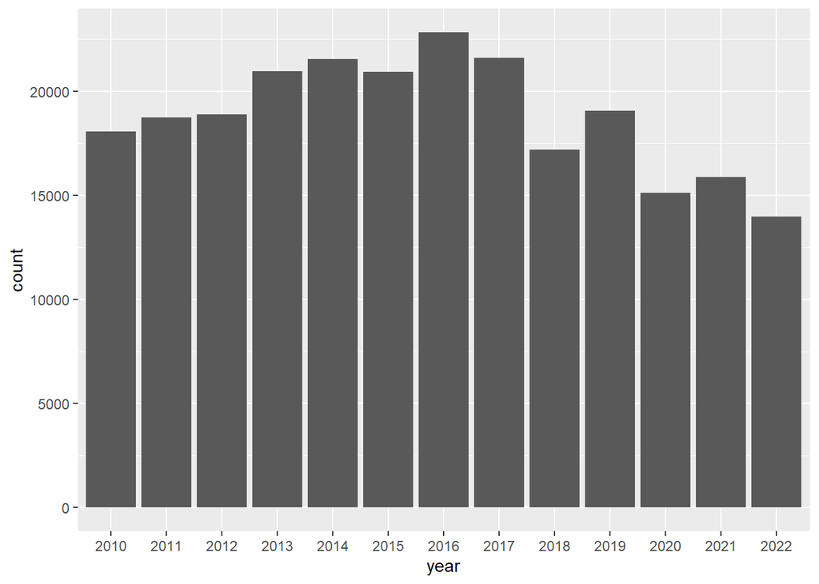

```r
#barchart(Freq~Var1, data=sum_yr)

ggplot(raw_fi, aes(x=year)) + geom_bar()
```

# Filtering and exploring food inspection data

So, we choose to work with 2019 data. The reason is that it is the most recent data before COVID-19. So, from here we would like to take Bakery and Grocery Store. Restaurant could be another choice, but we want to leave it given the timeframe and scope of this project. We are also specific about three inspection results that are pass, fail, and conditionally pass. Now there are many cases where one facility was inspected multiple times. To get things simpler, we retain only the first inspection result of 2019 for each facility. Finally, we will drop the NA values and make an sf object.

```r
fi_19 <- raw_fi %>%
  filter(year=="2019") %>% #filter only 2019 data
  filter(Facility.Type=="Bakery"|Facility.Type=="Grocery Store") %>%
  filter(Risk!="All")%>% # remove records whose risk level is ambiguous
  filter(Results!="No Entry",Results!="Not Ready",Results!="Out of Business", Results!="Business Not Located") %>% #only keep pass, fail, and conditional pass
  # get the unique food outlets from inspection data by address
  arrange(Inspection.Date) %>%
  group_by(Address) %>%
  summarise_all(first) %>%
  #create sf object after dropping the NA
  drop_na() %>%
  st_as_sf(coords = c("Longitude", "Latitude")) %>% # set coordinates
  st_set_crs("EPSG:4326") #set crs



st_write(fi_19,dsn = paste0("shapes/uniq_fi19.shp"),delete_dsn=T)
```

```
## Deleting source `shapes/uniq_fi19.shp' using driver `ESRI Shapefile'
## Writing layer `uniq_fi19' to data source
##   `shapes/uniq_fi19.shp' using driver `ESRI Shapefile'
## Writing 1027 features with 16 fields and geometry type Point.
```

Now we will check frequencies of different attributes.

```r
# crosstabs
xtabs(~Risk+Results, data=fi_19)
```

```
##                  Results
## Risk              Fail Pass Pass w/ Conditions
##   Risk 1 (High)    142   77                243
##   Risk 2 (Medium)  103   36                227
##   Risk 3 (Low)      77   28                 94
```

```r
xtabs(~Facility.Type+Results, data=fi_19)
```

```
##                Results
## Facility.Type   Fail Pass Pass w/ Conditions
##   Bakery          51   15                 85
##   Grocery Store  271  126                479
```

```r
colnames(fi_19)
```

```
##  [1] "Address"         "Inspection.ID"   "DBA.Name"        "AKA.Name"
##  [5] "License.."       "Facility.Type"   "Risk"            "City"
##  [9] "State"           "Zip"             "Inspection.Date" "Inspection.Type"
## [13] "Results"         "Violations"      "Location"        "year"
## [17] "geometry"
```

# aggregate records into census tracts

## Getting the study area shapes

We will download the census tracts boundaries and Chicago city boundary.

```r
#downloading census tracts of Cook county

ct <- tracts("Illinois", "Cook") %>% st_transform(crs = st_crs(fi_19))
#downloading chicago city boundary
chicago <- places("illinois") %>%
  filter(NAME=="Chicago") %>%
  st_transform(crs = st_crs(fi_19))
```

Then we will clip the tracts with the city boundary. The tract covering the lake should be removed. So we find out the GEOID of it and remove the shape by filtering the GEOID out.

```r
# mapping Cook county and Chicago city
tmap_mode("plot")
```

```
## tmap mode set to plotting
```

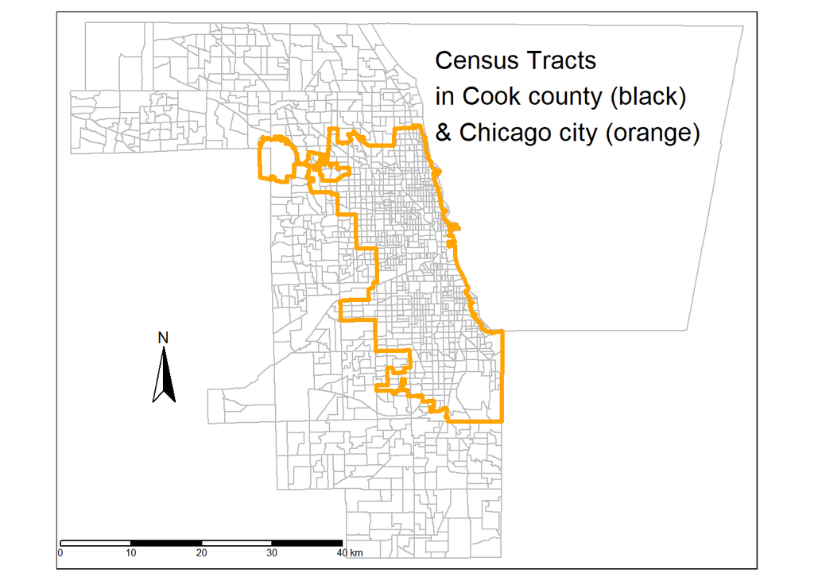

```r
tm_shape(ct) + tm_borders("gray") +
  tm_shape(chicago) + tm_borders("orange", lwd = 3.5) +
  tm_scale_bar(width = 0.32, position = c(0,.01)) +
  tm_compass(size=3,position = c(.1,.3)) +
  tm_layout(frame = T, title = "Census Tracts \nin Cook county (black)\n& Chicago city (orange)",
      title.size = 1.3, title.position = c(.54,.85), legend.outside = T, legend.position = c(.1,.5))
```

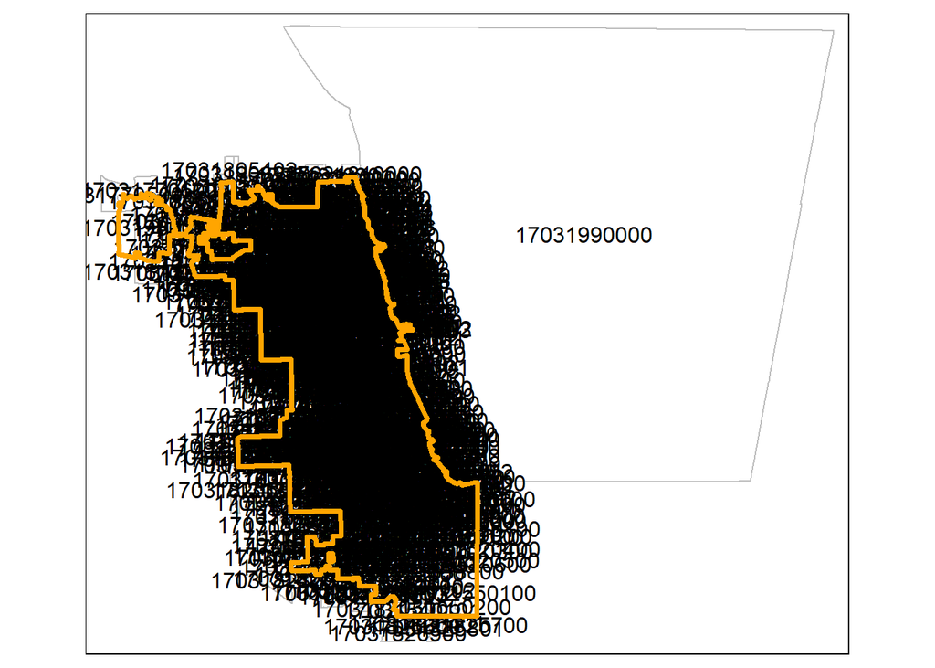

```r
# Clipping census tracts within city boundary
ct_C <- ct[chicago,]

# finding the GEOID of the lake and  removing that from filtered census tracts
tm_shape(ct_C) + tm_borders("gray") + tm_text("GEOID") +
  tm_shape(chicago) + tm_borders("orange", lwd = 3.5)
```

```r
# remove the particular tract
ct_C <- filter(ct_C, GEOID!="17031990000")

#save in local computer
st_write(ct_C,dsn = paste0("shapes/chicago_ct.shp"),delete_dsn=T)
```

```
## Deleting source `shapes/chicago_ct.shp' using driver `ESRI Shapefile'
## Writing layer `chicago_ct' to data source
##   `shapes/chicago_ct.shp' using driver `ESRI Shapefile'
## Writing 870 features with 12 fields and geometry type Multi Polygon.
```

## Mapping under facilities

Let’s have a look at the simple distribution of different facilities overlaid on tracts.

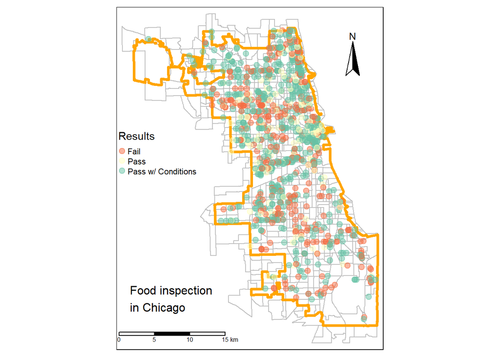

```r
# mapping of all locations in one frame

tm_shape(ct_C) + tm_borders("gray") +
  tm_shape(chicago) + tm_borders("orange", lwd = 3.5) +
  tm_shape(fi_19) + tm_dots("Results",alpha=0.5, size=.3, style = "cat",palette = "Spectral")+
  tm_scale_bar(width = 0.32, position = c(0,.01)) +
  tm_compass(size=3,position = c(.8,.8)) +
  tm_layout(frame = T, title = "Food inspection \nin Chicago",
      title.size = 1, title.position = c(.05,.15), legend.outside = F, legend.position = c(0,.5))
```

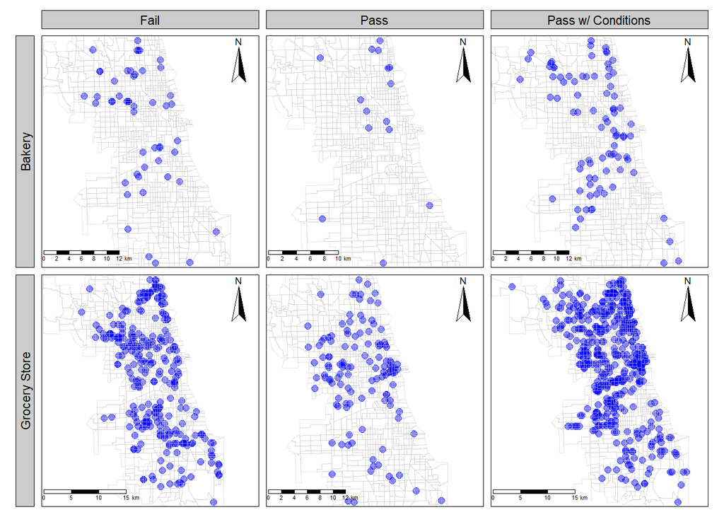

```r
# mapping of locations with different type and result in separate frame

tm_shape(fi_19) + tm_dots("blue", size=0.4, alpha=0.5) + tm_facets(by=c("Facility.Type","Results"), ncol  =2, showNA = FALSE) +
  tm_shape(ct_C) + tm_fill("black", alpha = 0, lwd = .5) + tm_borders("gray", lwd=0.2, alpha=0.4) +
  tm_scale_bar(width = 0.32, position = c(0,.01)) +
  tm_compass(size=3,position = c(.8,.8)) +
  tm_layout(frame = T,
      title.size = 1, title.position = c(.05,.15), legend.outside = T, legend.position = c(.1,.5))
```

## getting acs variables

We will download the sociodemographic variables from American Community Survey. We will collect population, number of white and black people, median household income, percentage of uninsured people, unemployment rate, percent of household with people under 18 years old and above 65 years old. Finally, we will join these datasets with the main census tract dataset (ct_C).

```r
demo <- c(tot_pop = "B01003_001", #population
          white_pop = "B01001A_001", # no of whites
          race_total = "B02001_001", # total popualtion
          race_black = "B02001_003")
          #hisp_pop = "DP05_071") # no. of blacks
eco <- c(med_income = "B06011_001", #median income
         insur_perc = "S2701_C03_001", #insurance rate
         unempl_rate="S2301_C04_001") #unemployment rate
hh<- c(hh18_perc = "S1101_C01_010", # HH with under 18
       hh65_perc = "S1101_C01_011") # HH with above 65

# downloading acs 5 year estimate of 2019 data for Illinois in tract level
demo_var <- get_acs(geography = "tract",
                    variables = demo,
                    output = "wide",
                    year  = 2019,
                    survey = "acs5",
                    state = "IL")
eco_var <- get_acs(geography = "tract",
                    variables = eco,
                    output = "wide",
                    year  = 2019,
                    survey = "acs5",
                    state = "IL")
```

```
## Fetching data by table type ("B/C", "S", "DP") and combining the result.
```

```r
hh_var <- get_acs(geography = "tract",
                    variables = hh,
                    output = "wide",
                    year  = 2019,
                    survey = "acs5",
                    state = "IL")
tracts19 <- left_join(demo_var,eco_var,by="GEOID")
tracts19 <- left_join(tracts19,hh_var,by="GEOID")

ct_C <- left_join(ct_C, tracts19, by = "GEOID")

head(ct_C)
```

```
## Simple feature collection with 6 features and 33 fields
## Geometry type: MULTIPOLYGON
## Dimension:     XY
## Bounding box:  xmin: -87.74918 ymin: 41.70268 xmax: -87.52399 ymax: 42.00537
## Geodetic CRS:  WGS 84
##   STATEFP COUNTYFP TRACTCE       GEOID NAME.x.x             NAMELSAD MTFCC
## 1      17      031  510300 17031510300     5103    Census Tract 5103 G5020
## 2      17      031  520100 17031520100     5201    Census Tract 5201 G5020
## 3      17      031  590700 17031590700     5907    Census Tract 5907 G5020
## 4      17      031  600400 17031600400     6004    Census Tract 6004 G5020
## 5      17      031  813801 17031813801  8138.01 Census Tract 8138.01 G5020
## 6      17      031  830600 17031830600     8306    Census Tract 8306 G5020
##   FUNCSTAT   ALAND AWATER    INTPTLAT     INTPTLON
## 1        S 2958348      0 +41.7157373 -087.5749771
## 2        S 2581898 521681 +41.7211184 -087.5294325
```

[output cut: 46 more lines]

In this stage, we will aggregate the number of different facilities in each census tract. First, we will join the GEOIDs with the facilities that they fall in.

```r
# join GEOID with inspection records

fi_19 <- st_join(fi_19, ct_C["GEOID"])


#let's have a look at the dataset structure
str(fi_19)
```

```
## sf [1,027 × 18] (S3: sf/tbl_df/tbl/data.frame)
##  $ Address        : chr [1:1027] "1 N HALSTED ST" "100 E WALTON ST" "1000 N CICERO AVE" "1000 N HAMLIN AVE" ...
##  $ Inspection.ID  : int [1:1027] 2303340 2320756 2352549 2300266 2261383 2288222 2288406 2312020 2345486 2252677 ...
##  $ DBA.Name       : chr [1:1027] "KIKKA AT WHOLE FOODS WEST LOOP" "HENDRIKX BELGIAN BREAD CRAFTER" "GOLDEN GROCERY STORE, LLC" "EXCLUSION FOOD MARKET" ...
##  $ AKA.Name       : chr [1:1027] "WHOLE FOODS" "HENDRIKX BELGIAN BREAD CRAFTER" "GOLDEN GROCERY" "EXCLUSION FOOD MARKET" ...
##  $ License..      : int [1:1027] 2385108 2026913 2695160 2670408 2641927 2663484 2284138 2689945 2374096 2516920 ...
##  $ Facility.Type  : chr [1:1027] "Grocery Store" "Bakery" "Grocery Store" "Grocery Store" ...
##  $ Risk           : chr [1:1027] "Risk 1 (High)" "Risk 1 (High)" "Risk 3 (Low)" "Risk 2 (Medium)" ...
##  $ City           : chr [1:1027] "CHICAGO" "CHICAGO" "CHICAGO" "CHICAGO" ...
##  $ State          : chr [1:1027] "IL" "IL" "IL" "IL" ...
##  $ Zip            : int [1:1027] 60661 60611 60651 60651 60651 60651 60607 60620 60640 60610 ...
##  $ Inspection.Date: Date[1:1027], format: "2019-07-18" "2019-10-30" ...
##  $ Inspection.Type: chr [1:1027] "Canvass" "Canvass" "License" "License" ...
##  $ Results        : chr [1:1027] "Pass" "Pass w/ Conditions" "Pass w/ Conditions" "Pass" ...
##  $ Violations     : chr [1:1027] "" "3. MANAGEMENT, FOOD EMPLOYEE AND CONDITIONAL EMPLOYEE; KNOWLEDGE, RESPONSIBILITIES AND REPORTING - Comments: OB"| __truncated__ "5. PROCEDURES FOR RESPONDING TO VOMITING AND DIARRHEAL EVENTS - Comments: ** PREMISES HAS NO CLEAN UP PROCEDURE"| __truncated__ "" …
##  $ Location       : chr [1:1027] "(41.88181563164203, -87.64721471704077)" "(41.90009662517738, -87.62535934070077)" "(41.89872983060618, -87.74603871315406)" "(41.89915058623179, -87.72146228597416)" ...
##  $ year           : chr [1:1027] "2019" "2019" "2019" "2019" ...
##  $ geometry       :sfc_POINT of length 1027; first list element:  'XY' num [1:2] -87.6 41.9
##  $ GEOID          : chr [1:1027] "17031280100" "17031081201" "17031251000" "17031231200" ...
##  - attr(*, "sf_column")= chr "geometry"
##  - attr(*, "agr")= Factor w/ 3 levels "constant","aggregate",..: NA NA NA NA NA NA NA NA NA NA ...
##   ..- attr(*, "names")= chr [1:17] "Address" "Inspection.ID" "DBA.Name" "AKA.Name" ...
```

```r
#also check how many points are outside of Chicago
sum(is.na(fi_19$GEOID))
```

```
## [1] 0
```

```r
#ct_C <- st_as_sf(ct_C)  #
#ct_C <- spTransform(ct_C,crs(fi_19))
```

Then we will create dummies to indicate the attributes of the facilities. For aggregation, we will group by GEOID and summarize the dummies. In this way, we will get the counts of different types. We will join the aggregated data with the main census tract data by GEOID key. Finally, from the count, we will create the percentages of facilities in each tract that passed, failed, or conditionally passed.

```r
# make dummy variables for summarizing
fi19_df <- dummy_cols(fi_19, select_columns = c("Risk","Results", "Facility.Type"))

colnames(fi_19)
```

```
##  [1] "Address"         "Inspection.ID"   "DBA.Name"        "AKA.Name"
##  [5] "License.."       "Facility.Type"   "Risk"            "City"
##  [9] "State"           "Zip"             "Inspection.Date" "Inspection.Type"
## [13] "Results"         "Violations"      "Location"        "year"
## [17] "geometry"        "GEOID"
```

```r
#aggregate by GEOID
fi19_df <- fi19_df %>% st_drop_geometry() %>% group_by(GEOID) %>% summarise(high_risk = sum(`Risk_Risk 1 (High)`),medium_risk = sum(`Risk_Risk 2 (Medium)`), low_risk=sum(`Risk_Risk 3 (Low)`), pass=sum(Results_Pass), fail=sum(Results_Fail), cond_pass=sum(`Results_Pass w/ Conditions`),bakery=sum(Facility.Type_Bakery),grocery=sum(`Facility.Type_Grocery Store`))

# join the aggregated table with block group dataframe

ct_C <-  left_join(ct_C, fi19_df, by="GEOID")

ct_C[is.na(ct_C)] = 0 # replace NA with 0


summary(ct_C$pass) #examine one field
```

```
##    Min. 1st Qu.  Median    Mean 3rd Qu.    Max.
##  0.0000  0.0000  0.0000  0.1621  0.0000  3.0000
```

```r
ct_C <- ct_C %>% mutate(total=grocery+bakery)%>%
  mutate(pass_perc = pass/total*100, fail_perc = fail/total*100, cond_pass_perc = cond_pass/total*100)
```

## map aggregated distributions of facilities

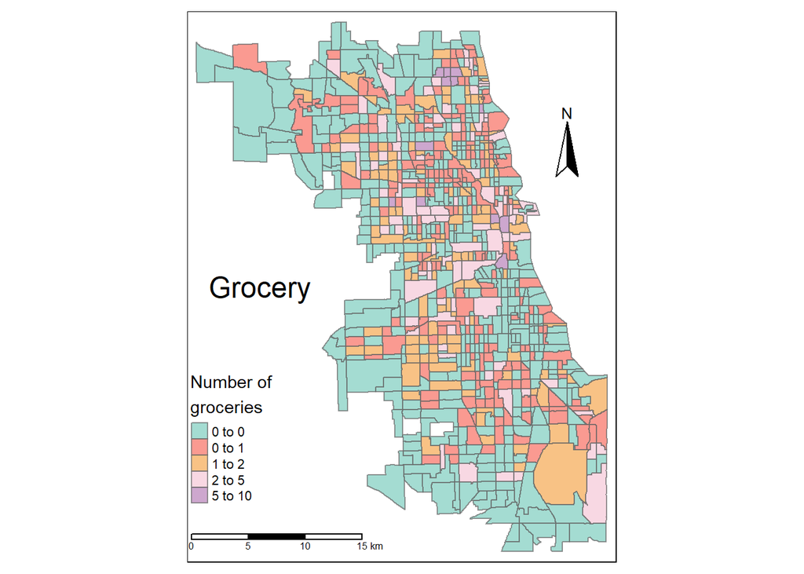

```r
tm_shape(ct_C) + tm_polygons("grocery", alpha=0.8, style = "jenks",palette = "Set3",
              border.alpha=0.7, title = "Number of \ngroceries") + tm_borders("gold", lty = "dashed") +
  tm_scale_bar(width = 0.32, position = c(0,.01)) +
  tm_compass(size=3,position = c(.8,.7)) +
  tm_layout(frame = T, title = "Grocery",
      title.size = 1.5, title.position = c(.05,.5), legend.outside = F, legend.position = c(0,.1))
```

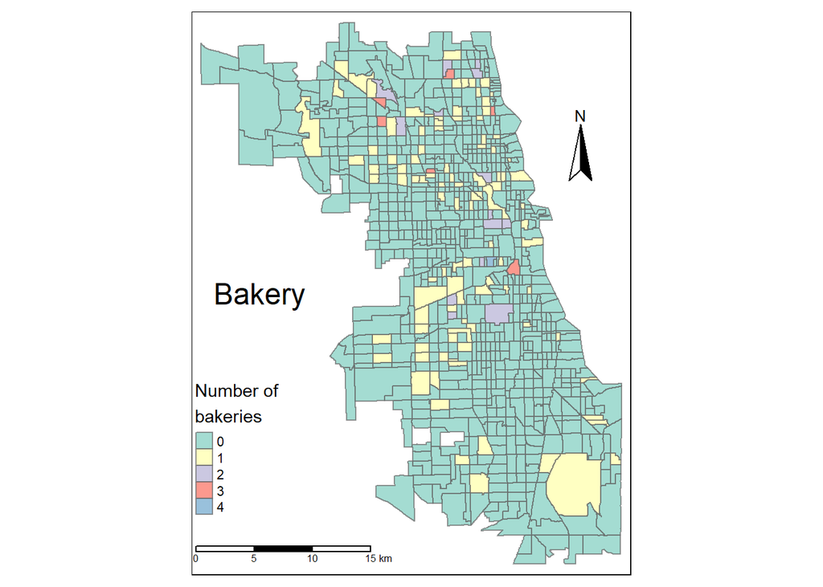

```r
tm_shape(ct_C) + tm_polygons("bakery", alpha=0.8, style = "cat",palette = "Set3",
              border.alpha=0.7, title = "Number of \nbakeries") + tm_borders("gold", lty = "dashed") +
  tm_scale_bar(width = 0.32, position = c(0,.01)) +
  tm_compass(size=3,position = c(.8,.7)) +
  tm_layout(frame = T, title = "Bakery",
      title.size = 1.5, title.position = c(.05,.5), legend.outside = F, legend.position = c(0,.1))
```

## map aggregated distributions of the results of inspection

```r
p<-tm_shape(ct_C) + tm_polygons("pass_perc", alpha=0.8, style = "jenks",palette = "Spectral",
              border.alpha=0.3, title = "Percentage of \nfacility passed") + tm_borders("gold",lwd=0.1, lty = "dashed") +
  tm_scale_bar(width = 0.32, position = c(0,.01)) +
  tm_compass(size=3,position = c(.8,.7)) +
  tm_layout(frame = T, title = "Pass",
      title.size = 1.5, title.position = c(.05,.5), legend.outside = F, legend.position = c(0,.1))



f<-tm_shape(ct_C) + tm_polygons("fail_perc", alpha=0.8, style = "jenks",palette = "Set3",
              border.alpha=0.3, title = "Percent of \nfacility failed") + tm_borders("gold",lwd=0.1, lty = "dashed") +
  tm_scale_bar(width = 0.32, position = c(0,.01)) +
  tm_compass(size=3,position = c(.8,.7)) +
  tm_layout(frame = T, title = "Fail",
      title.size = 1.5, title.position = c(.05,.5), legend.outside = F, legend.position = c(0,.1))

cp<-tm_shape(ct_C) + tm_polygons("cond_pass_perc", alpha=0.8, style = "jenks",palette = "Set2",
              border.alpha=0.7, title = "Perc of facility \nconditionally \npassed") + tm_borders("gold", lwd=0.1,lty = "dashed") +
  tm_scale_bar(width = 0.32, position = c(0,.01)) +
  tm_compass(size=3,position = c(.8,.7)) +
  tm_layout(frame = T, title = "Condional \nPass",
      title.size = 1.5, title.position = c(0,.6), legend.outside = F, legend.position = c(0,.1))

tmap_arrange(p,f,cp)
```

```
## Some legend labels were too wide. These labels have been resized to 0.66, 0.66, 0.66, 0.60. Increase legend.width (argument of tm_layout) to make the legend wider and therefore the labels larger.
```

```
## Some legend labels were too wide. These labels have been resized to 0.66, 0.66, 0.66, 0.60. Increase legend.width (argument of tm_layout) to make the legend wider and therefore the labels larger.
```

```
## Some legend labels were too wide. These labels have been resized to 0.66, 0.66, 0.66, 0.60. Increase legend.width (argument of tm_layout) to make the legend wider and therefore the labels larger.
```

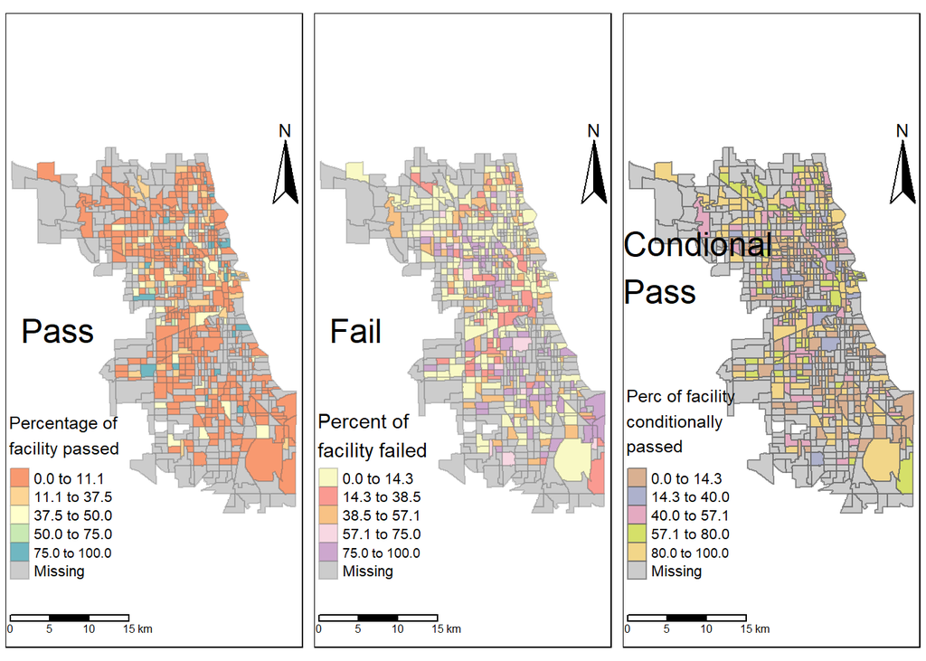

# accessibility

## Gathering data to calculate accessibility

In the following code, we tried to collect the supply variable of food facilities (i.e., number of employees). However, several problems were encountered while doing so. 1. Multiple business locations in one address were found which will take much time for us to clean. 2. Substantial amount of places do not match with business dataset and thus it reduces the number of facilities to analyze. So, we left this part for future extension of this work and hereby did not run the code in knitting.

```r
# importing the business location dataset
business <- read.csv("C:/study/1_OSU/fall 22/lab2/final project/business data/BUSINESS_HISTORICAL_2019/Business_2019_IL.csv", header = F)


population <- read.csv("C:/study/1_OSU/test/ACSDT5Y2020.B01003_2024-02-20T112330/ACSDT5Y2020.B01003-Data.csv")

#select specified columns
business <- business %>% subset(select=c("V1","V2","V10","V11","V13", "V15", "V47","V48"))
#rename column names
colnames(business) <- c("Company", "Address", "Employee", "Sales","SIC", "NAICS", "Lattitude", "Longitude")



#join business data (with multiple business in one address)
fi19_biz <- left_join(uniq_fi19F, business,by="Address")

# finding frequency of facilities
dup <- as.data.frame(table(fi19_biz$DBA.Name))

#dup$Freq<- as.factor(dup$Freq)
#dup$Freq<- as.integer(dup$Freq)
#summary(dup$Freq)

dup1 <- filter(dup, Freq==1)
colnames(dup1)[1] = "DBA.Name"

fi19_bizU <- inner_join(fi19_biz, dup1, by="DBA.Name")

head(fi19_bizU)

View(uniq_fi19)
table(uniq_fi19F$Results)
table(fi_19$Results)


colnames(fi_19)
dup_fi <- as.data.frame(table(fi_19$DBA.Name))
nrow(dup_fi)
View(uniq_fi19)

x <- fi19_biz[grep(fi19_biz$DBA.Name, fi19_biz$Company), ]

library(stringi)
x <- str_detect(fi19_biz$DBA.Name, fi19_biz$Company)

fi19_biz<- fi19_biz %>%
  rowwise() %>%
  mutate(matched =
           grepl(DBA.Name, Company)
       )


head(fi19_biz)



View(fi19_bizDup)

nrow(dup2_5)

sum(dup_fi$Freq==1)

sum(is.na(fi19_bizU$SIC))

head(fi19_biz)
nrow(fi19_bizU)
```

## getting the travel time matrix

There are several ways to obtain travel time matrix which is a required part of 2SFCA calculation. We had technical issued in local computer while using R5R and Opentripplanner for travel time matrix. Therefore, we used ArcGIS Pro Network Analyst tool for this. With the centroid of census tracts as origin and locations of food outlets as destination, we calculated origin-destination matrix. In the following code, we first import the OD line layer from the geodatabase. Then we connect the originID (GEOID) and destinationID (Inspection ID) from origin and destination layer to the OD layer. With these keys, we can get the demographic information (population) and food inspection information (facility type, results, etc).

```r
fgdb <- "C:/study/1_OSU/fall 22/lab2/final project/food_inspection/food_inspection.gdb"

# List all feature classes in a file geodatabase
subset(ogrDrivers(), grepl("GDB", name))
fc_list <- ogrListLayers(fgdb)
print(fc_list) # to see which files I have in the geodatabase

# Read the feature class
fc <- readOGR(dsn=fgdb,layer="ODLinesieif3w") # read the lines (OD matrix)

orig <- readOGR(dsn=fgdb,layer="Origins_SpatialJoin") %>% as.data.frame() # origin location
dest <- readOGR(dsn=fgdb,layer="Dest_SpatialJoin")%>% as.data.frame() #destination location


# rename
colnames(orig)[2]="OriginID"
colnames(dest)[2]="DestinationID"

OD <- st_as_sf(fc)

# join
OD <- left_join(OD,orig,by="OriginID")
OD <- left_join(OD,dest,by="DestinationID")

OD <- OD %>% subset(select=c("Total_TravelTime","Total_Kilometers","GEOID","Insp_ID"))

ct_pop <- ct_C %>% subset(select=c("GEOID","tot_popE")) %>% st_drop_geometry()

OD <- left_join(OD,ct_pop,by="GEOID")
colnames(OD)[4]="Inspection.ID"
fi19_df <- fi_19 %>% st_drop_geometry()
OD <- left_join(OD,fi19_df,by="Inspection.ID")

head(OD)

table(OD$Facility.Type)
```

The OD matrix is large containing 869,000 line features. So, we will write the processed matrix as dataframe and then import it again to save knitting time.

```r
OD_df <- OD %>% st_drop_geometry()
OD_csv <- write.csv(OD_df, "OD.csv")
```

```r
# reading from local computer

OD <- read.csv("OD.csv")
colnames(OD)[4]="GEOID"

OD$GEOID <- as.character(OD$GEOID)
```

## Calculating 2SFCA (without true supply variable)

If we have the supply variable, the probable interpretation of the accessibility score would be the number of employees per certain number of population within certain travel time. Since we do not have it now, we used every facility with same weight which is simply their existence. So, we used 1 (for the count) and divided it by the population of catchment area to get the supply ratio. The interpretation now is the number of facilities per 1000 population within t travel time.

### passed grocery

```r
OD_filt <- filter(OD, Facility.Type=="Grocery Store", Results=="Pass") #filter the only records we need (e.g., passed groceries)

supply_ratio <- OD_filt  %>%
  st_drop_geometry(OD_filt) %>%
  filter(Total_TravelTime<15) %>% # Within certain travel time (travel time cutoff)
  group_by(Inspection.ID) %>% # from each facility
  filter(!is.na(tot_popE))%>%
  summarise(sumpop=sum(tot_popE))%>% #count the population within the catchment
  mutate(ratio = 1/sumpop) #this is the contribution of the facility to one person

demand = merge(x=OD_filt, y=supply_ratio, by="Inspection.ID", all.x=TRUE) #additing this ratio table

demand2 <- demand %>%
  #st_drop_geometry(demand) %>%
  filter(Total_TravelTime<15) %>% #within the catchment around census tract
  group_by(GEOID)  %>% #from each census tract
  summarise(ac_grocP=1000*sum(ratio)) %>% # taking taking sum of the ratios (contribution to one person) and multiply by 1000
  st_drop_geometry()

ct_C <- ct_C %>%
  left_join(demand2, by = "GEOID")

colnames(fi_19)
```

```
##  [1] "Address"         "Inspection.ID"   "DBA.Name"        "AKA.Name"
##  [5] "License.."       "Facility.Type"   "Risk"            "City"
##  [9] "State"           "Zip"             "Inspection.Date" "Inspection.Type"
## [13] "Results"         "Violations"      "Location"        "year"
## [17] "geometry"        "GEOID"
```

### failed grocery

```r
OD_filt <- filter(OD, Facility.Type=="Grocery Store", Results=="Fail")

supply_ratio <- OD_filt  %>%
  st_drop_geometry(OD_filt) %>%
  filter(Total_TravelTime<15) %>%
  group_by(Inspection.ID) %>%
  filter(!is.na(tot_popE))%>%
  summarise(sumpop=sum(tot_popE))%>%
  mutate(ratio = 1/sumpop)

demand = merge(x=OD_filt, y=supply_ratio, by="Inspection.ID", all.x=TRUE)

demand2 <- demand %>%
  filter(Total_TravelTime<15) %>%
  group_by(GEOID)  %>%
  summarise(ac_grocF=1000*sum(ratio)) %>%
  st_drop_geometry()

ct_C <- ct_C %>%
  left_join(demand2, by = "GEOID")
```

### grocery that passed with condition

```r
OD_filt <- filter(OD, Facility.Type=="Grocery Store", Results=="Pass w/ Conditions")

supply_ratio <- OD_filt  %>%
  st_drop_geometry(OD_filt) %>%
  filter(Total_TravelTime<15) %>%
  group_by(Inspection.ID) %>%
  filter(!is.na(tot_popE))%>%
  summarise(sumpop=sum(tot_popE))%>%
  mutate(ratio = 1/sumpop)

demand = merge(x=OD_filt, y=supply_ratio, by="Inspection.ID", all.x=TRUE)

demand2 <- demand %>%
  filter(Total_TravelTime<15) %>%
  group_by(GEOID)  %>%
  summarise(ac_groCP=1000*sum(ratio)) %>%
  st_drop_geometry()

ct_C <- ct_C %>%
  left_join(demand2, by = "GEOID")
```

### Passed bakery

```r
OD_filt <- filter(OD, Facility.Type=="Bakery", Results=="Pass")

supply_ratio <- OD_filt  %>%
  st_drop_geometry(OD_filt) %>%
  filter(Total_TravelTime<15) %>%
  group_by(Inspection.ID) %>%
  filter(!is.na(tot_popE))%>%
  summarise(sumpop=sum(tot_popE))%>%
  mutate(ratio = 1/sumpop)

demand = merge(x=OD_filt, y=supply_ratio, by="Inspection.ID", all.x=TRUE)

demand2 <- demand %>%
  filter(Total_TravelTime<15) %>%
  group_by(GEOID)  %>%
  summarise(ac_bakP=1000*sum(ratio)) %>%
  st_drop_geometry()

ct_C <- ct_C %>%
  left_join(demand2, by = "GEOID")
```

### Failed bakery

```r
OD_filt <- filter(OD, Facility.Type=="Bakery", Results=="Fail")

supply_ratio <- OD_filt  %>%
  st_drop_geometry(OD_filt) %>%
  filter(Total_TravelTime<15) %>%
  group_by(Inspection.ID) %>%
  filter(!is.na(tot_popE))%>%
  summarise(sumpop=sum(tot_popE))%>%
  mutate(ratio = 1/sumpop)

demand = merge(x=OD_filt, y=supply_ratio, by="Inspection.ID", all.x=TRUE)

demand2 <- demand %>%
  filter(Total_TravelTime<15) %>%
  group_by(GEOID)  %>%
  summarise(ac_bakF=1000*sum(ratio)) %>%
  st_drop_geometry()

ct_C <- ct_C %>%
  left_join(demand2, by = "GEOID")
```

### Bakeries that passed with condition

```r
OD_filt <- filter(OD, Facility.Type=="Bakery", Results=="Pass w/ Conditions")

supply_ratio <- OD_filt  %>%
  st_drop_geometry(OD_filt) %>%
  filter(Total_TravelTime<15) %>%
  group_by(Inspection.ID) %>%
  filter(!is.na(tot_popE))%>%
  summarise(sumpop=sum(tot_popE))%>%
  mutate(ratio = 1/sumpop)

demand = merge(x=OD_filt, y=supply_ratio, by="Inspection.ID", all.x=TRUE)

demand2 <- demand %>%
  filter(Total_TravelTime<15) %>%
  group_by(GEOID)  %>%
  summarise(ac_bakCP=1000*sum(ratio)) %>%
  st_drop_geometry()

ct_C <- ct_C %>%
  left_join(demand2, by = "GEOID")
```